# **Classification of Emotions in Texts**

**The goal of the project is the automatic classification of emotions in texts.** The model will be trained on a dataset containing texts with numerical labels assigned to emotions:

- sadness (0)
- joy (1)
- love (2)
- anger (3)
- fear (4)
- surprise (5)

The final product will be a tool that enables the **automatic recognition of the dominant emotion in any given text**.

Thanks to automatic emotion recognition, large sets of product and service reviews can be quickly analyzed, allowing for the efficient identification of problems and positive aspects that deserve attention. This approach allows for faster responses to issues, **improving the quality of customer service**. The early detection of negative emotions can help **prevent customer loss**, while a deeper understanding of customer sentiment enables **precise tailoring of offers to their needs**.

Additionally, the tool can be used for **monitoring comments and opinions**, as well as for **content personalization**. As a result, it becomes possible to **better understand customer needs** and **build trust**, which ultimately leads to **improved financial performance** for the company.

### Importing Libraries

```python
# Remove warnings
import warnings
warnings.filterwarnings('ignore')
import sys
import os
# Save the original stdout and stderr
original_stdout = sys.stdout
original_stderr = sys.stderr
# Redirecting output to "black hole"
sys.stdout = open(os.devnull, 'w')
sys.stderr = open(os.devnull, 'w')

# Data processing
import pandas as pd
import numpy as np

import matplotlib.pyplot as plt
import seaborn as sns
import statistics
from tabulate import tabulate

# Text preprocessing
import string
import spacy

# Tokenization
from sklearn.feature_extraction.text import CountVectorizer
from nltk import word_tokenize
from tensorflow.keras.preprocessing.text import Tokenizer
from tensorflow.keras.preprocessing import sequence
from keras.preprocessing.sequence import pad_sequences
from torchtext.data.utils import get_tokenizer
from sklearn.feature_extraction.text import TfidfVectorizer

# Hugging Face Dataset
from datasets import Dataset

# Splitting Data
from sklearn.model_selection import train_test_split

# Undersampling
from imblearn.under_sampling import RandomUnderSampler

# Models
 ## SVC
from sklearn.svm import LinearSVC
 ## LSTM
from tensorflow.keras.models import Sequential
from tensorflow.keras.layers import Dense, Embedding, LSTM, SpatialDropout1D
 ## Transformers
import tensorflow as tf
from transformers import AutoTokenizer, AutoModelForSequenceClassification, TrainingArguments, Trainer, EarlyStoppingCallback, TextClassificationPipeline
import torch

# Metrics
import sklearn.metrics as metrics
from sklearn.metrics import confusion_matrix
from sklearn.metrics import classification_report
from sklearn.metrics import f1_score

# Model performance evaluation
!pip install evaluate
import evaluate

# Additional settings
os.environ['TF_CPP_MIN_LOG_LEVEL'] = '3'
tf.get_logger().setLevel('ERROR')

# Restoring standard output
sys.stdout = original_stdout
sys.stderr = original_stderr
```

# **1. Loading the Dataset**

```python
os.listdir('/kaggle/input/emotionstext')

Data = pd.read_csv('/kaggle/input/emotionstext/text.csv')
```

```python
Data.head()
```

|  | Unnamed: 0 | text | label |
| --- | --- | --- | --- |
| 0 | 0 | i just feel really helpless and heavy hearted | 4 |
| 1 | 1 | ive enjoyed being able to slouch about relax a... | 0 |
| 2 | 2 | i gave up my internship with the dmrg and am f... | 4 |
| 3 | 3 | i dont know i feel so lost | 0 |
| 4 | 4 | i am a kindergarten teacher and i am thoroughl... | 4 |

# **2. Dataset Characteristics**

### Data Frame Dimensions

```python
Data.shape
```

```
(416809, 3)
```

The data frame consists of **416 809 observations** and **3 columns**.

```python
Data.info()
```

```
<class 'pandas.core.frame.DataFrame'>
RangeIndex: 416809 entries, 0 to 416808
Data columns (total 3 columns):
 #   Column      Non-Null Count   Dtype
---  ------      --------------   -----
 0   Unnamed: 0  416809 non-null  int64
 1   text        416809 non-null  object
 2   label       416809 non-null  int64
dtypes: int64(2), object(1)
memory usage: 9.5+ MB
```

From the results, we can see that this dataset contains 416 809 records and has **no missing data**. The 'text' column is of *object* type, while the other two columns are of *int64* type.

### Checking for Missing Values

```python
Data.isnull().sum()
```

```
Unnamed: 0    0
text          0
label         0
dtype: int64
```

The result confirms that there are no missing values in any of the columns. This means that all 416 809 observations are complete and contain information in each column.

### 'text' Column

The '*text*' column contains statements assigned to given emotions. Let's take a look at what these statements look like.

```python
Data.text
```

```
0             i just feel really helpless and heavy hearted
1         ive enjoyed being able to slouch about relax a...
2         i gave up my internship with the dmrg and am f...
3                                i dont know i feel so lost
4         i am a kindergarten teacher and i am thoroughl...
                                ...
416804    i feel like telling these horny devils to find...
416805    i began to realize that when i was feeling agi...
416806    i feel very curious be why previous early dawn...
416807    i feel that becuase of the tyranical nature of...
416808    i think that after i had spent some time inves...
Name: text, Length: 416809, dtype: object
```

The sentences appear to be pre-processed — they contain only text, written in lowercase, without any punctuation marks.

### Class Frequencies

```python
Data["label"].value_counts()
```

```
label
1    141067
0    121187
3     57317
4     47712
2     34554
5     14972
Name: count, dtype: int64
```

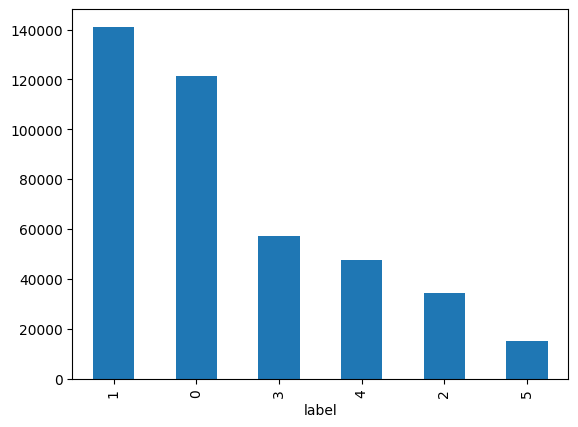

```python
Data.label.value_counts().plot(kind='bar')
```

The distribution of categories is uneven. **The dominant class is 'joy' (1)**, while **the least frequent class is 'surprise' (5)**.

### Histogram of Expression Lengths

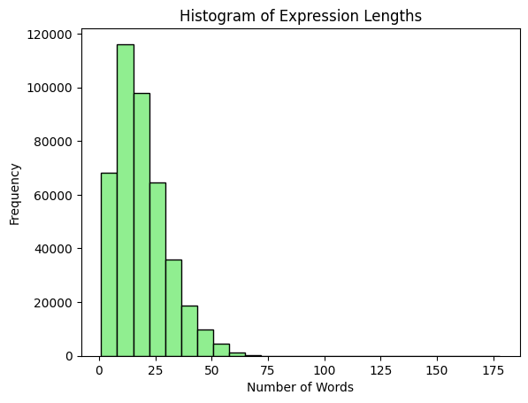

```python
w = Data['text'].apply(lambda x: len(x.split())) #vector that will store the lengths of the expressions


plt.hist(w, bins=25, color='lightgreen', edgecolor='black')
plt.xlabel('Number of Words')
plt.ylabel('Frequency')
plt.title('Histogram of Expression Lengths')
plt.show()
```

##### Statistics

```python
print(f"The maximum length of an expression is: {max(w)}")
print(f"The minimum length of an expression is: {min(w)}")
print(f"The average length of an expression is: {round(statistics.mean(w))}")
print(f"The median length of an expression is: {round(statistics.median(w))}")
```

```
The maximum length of an expression is: 178
The minimum length of an expression is: 1
The average length of an expression is: 19
The median length of an expression is: 17
```

```python
sorted(w, reverse=True)[:10]
```

```
[178, 110, 101, 100, 100, 94, 80, 79, 78, 77]
```

The expressions are not very wordy, typically containing up to *50* words. On average, each expression contains about *19* words. However, there is one expression that is quite long, consisting of *178* words, making it much longer than the others.

#### Histogram of Expression Lengths for Each Category Separately

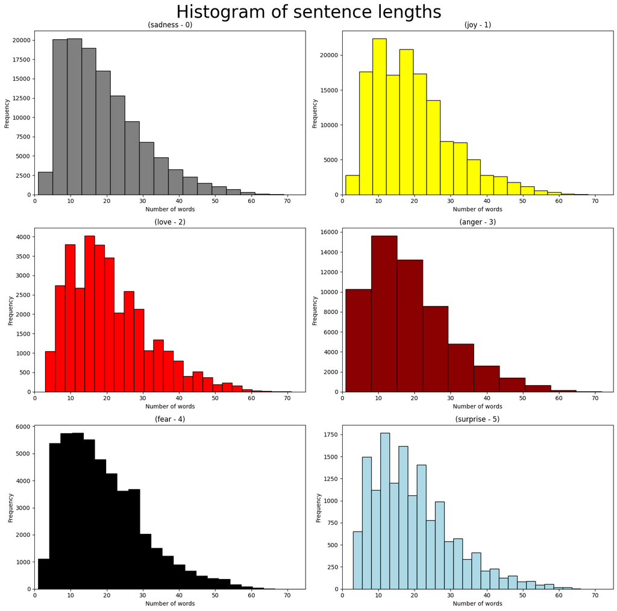

```python
colors = ['grey', 'yellow', 'red', 'darkred', 'black', 'lightblue']

titles = [
    '(sadness - 0)',
    '(joy - 1)',
    '(love - 2)',
    '(anger - 3)',
    '(fear - 4)',
    '(surprise - 5)']

labels = ['sadness', 'joy', 'love', 'anger', 'fear', 'surprise']

# Creating Subplots
fig, axes = plt.subplots(3, 2, figsize=(15, 15))
axes = axes.flatten()

# Initializing an empty list to collect statistics
stats_list = []

for i, label in enumerate(range(6)):
    Datal = Data[Data['label'] == label].reset_index(drop=True)

    # Calculating expression lengths (Word Count in each text)
    w = Datal['text'].apply(lambda x: len(x.split()))

    # Plotting the Histogram
    ax = axes[i]
    ax.hist(w, bins=25, color=colors[i], edgecolor='black')
    ax.set_xlim(0, 75)  # Ustawienie zakresu osi x od 0 do 175
    ax.set_xlabel('Number of words')
    ax.set_ylabel('Frequency')
    ax.set_title(titles[i])

    # Collecting Statistics
    max_length = max(w)
    min_length = min(w)
    mean_length = statistics.mean(w)
    median_length = statistics.median(w)

    # Adding Statistics to the List as a Dictionary
    stats_list.append({
        'Label': labels[i],
        'Max': max_length,
        'Min': min_length,
        'Mean': round(mean_length),
        'Median': round(median_length)
    })

fig.suptitle('Histogram of sentence lengths', fontsize=30)

plt.tight_layout()
plt.show()
```

Based on the histograms of expression lengths for each emotion category (sadness, joy, love, anger, fear, surprise), we can observe that the graphs have different shapes, indicating a variety of expression styles depending on the emotion.

Most of the histograms peak in the range of 10 to 30 words, suggesting that the majority of texts, regardless of emotion, are **relatively short**.

We also notice that texts associated with the emotions *sadness* and *fear* tend to be **shorter** than those linked to *joy*, *love*, or *surprise*.

However, there are no significant differences among the various categories.

##### Statistics

```python
stats_df = pd.DataFrame(stats_list)
stats_df
```

|  | Label | Max | Min | Mean | Median |
| --- | --- | --- | --- | --- | --- |
| 0 | sadness | 101 | 1 | 18 | 16 |
| 1 | joy | 94 | 1 | 20 | 17 |
| 2 | love | 71 | 3 | 21 | 19 |
| 3 | anger | 178 | 1 | 19 | 17 |
| 4 | fear | 79 | 1 | 19 | 17 |
| 5 | surprise | 66 | 3 | 20 | 18 |

The emotion '*anger*' has the highest maximum value - 178. However, both the average and median lengths of expressions in this category are not relatively high. This suggests that while there are very long expressions of anger, they are quite rare, and most expressions in this category tend to be shorter.

**Positive emotions** such as '*joy*', '*love*', and '*surprise*' **show higher average and median lengths of expressions**. This may indicate that positive emotions encourage longer and more elaborate statements.

On the other hand, emotions considered less positive, such as '*sadness*', '*anger*', and '*fear*', are associated with shorter expression lengths.

### Removing Stopwords

The most frequently occurring words in each subgroup are stopwords, which are not significant in the context of analysis. We will remove them to focus on words that truly stand out in each subgroup, allowing for a more accurate analysis and differentiation between categories.

To achieve this, we will create a **preprocess function** that:

1. Convert all letters to lowercase
2. Remove punctuation marks
3. Remove stopwords
4. Apply lemmatization to reduce words to their base forms.

```python
nlp = spacy.load("en_core_web_sm")

def preprocess(text):
    # 1. Convert to lowercase
    text = text.lower()

    # 2. Removal of punctuations
    text = text.translate(str.maketrans('', '', string.punctuation))

    # 3. Removal of stopwords and lemmatization
    doc = nlp(text)
    text = [token.lemma_ for token in doc if not token.is_stop]

    return " ".join(text)
```

We will create a new column that will contain the processed text.

```python
#Data['preprocessed_text'] = Data['text'].apply(lambda x: preprocess(x))
```

Since this process is time-consuming, to avoid repeating it in the future and to streamline further work, we will save the data frame to a file.

```python
#Data.to_csv('/kaggle/working/Data_preprocess.csv', index=False)
#print(os.listdir('/kaggle/input/text-preprocess'))
Data = pd.read_csv('/kaggle/input/text-preprocess/Data_preprocess.csv')
```

Let’s take a look at how the lengths of the expressions appear now.

### Histogram of Expression Lengths (Preprocessed text)

Additionally, to avoid issues related to missing values during further text analysis, we will replace all missing values (NaN) in the *preprocessed_text* column with empty strings ('').

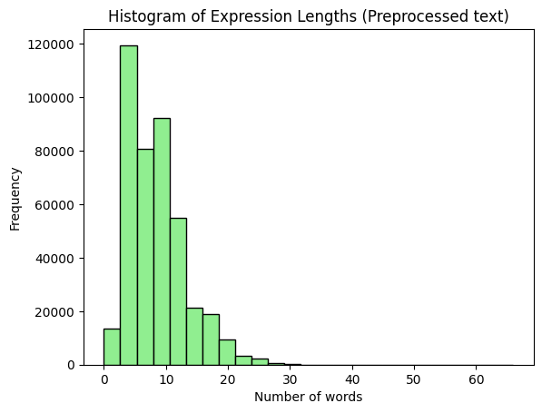

```python
Data['preprocessed_text'] = Data['preprocessed_text'].fillna('')
w2 = Data['preprocessed_text'].apply(lambda x: len(x.split()))


plt.hist(w2, bins=25, color='lightgreen', edgecolor='black')
plt.xlabel('Number of words')
plt.ylabel('Frequency') #liczebność, density-częstość
plt.title('Histogram of Expression Lengths (Preprocessed text)')
plt.show()
```

##### Statistics

```python
print(f"The maximum length of an expression is: {max(w2)}")
print(f"The minimum length of an expression is: {min(w2)}")
print(f"The average length of an expression is: {round(statistics.mean(w2))}")
print(f"The median length of an expression is: {round(statistics.median(w2))}")
```

```
The maximum length of an expression is: 66
The minimum length of an expression is: 0
The average length of an expression is: 8
The median length of an expression is: 7
```

Now, the expressions consist of even fewer words, averaging *8* words each. The longest phrase is *66* words long, but the vast majority of phrases are no longer than *30* words.

```python
stats_list = []

for i, label in enumerate(range(6)):
    Datal = Data[Data['label'] == label].reset_index(drop=True)

    # Calculating expression lengths (Word Count in each text)
    w2 = Datal['preprocessed_text'].apply(lambda x: len(x.split()))

    # Collecting Statistics
    max_length = max(w2)
    min_length = min(w2)
    mean_length = statistics.mean(w2)
    median_length = statistics.median(w2)

    # Adding Statistics to the List as a Dictionary
    stats_list.append({
        'Label': labels[i],
        'Max': max_length,
        'Min': min_length,
        'Mean': round(mean_length),
        'Median': round(median_length)
    })


stats_df = pd.DataFrame(stats_list)
stats_df
```

|  | Label | Max | Min | Mean | Median |
| --- | --- | --- | --- | --- | --- |
| 0 | sadness | 39 | 0 | 8 | 7 |
| 1 | joy | 41 | 0 | 8 | 8 |
| 2 | love | 47 | 2 | 9 | 8 |
| 3 | anger | 66 | 0 | 8 | 7 |
| 4 | fear | 38 | 0 | 8 | 7 |
| 5 | surprise | 39 | 2 | 9 | 8 |

### Word Frequencies in Classes

We will create a chart showcasing the most frequently occurring words in each subgroup, excluding stopwords. Additionally, we will remove words that are commonly found across the subgroups (such as 'feel', which appears most frequently) to better differentiate vocabulary across subgroups.

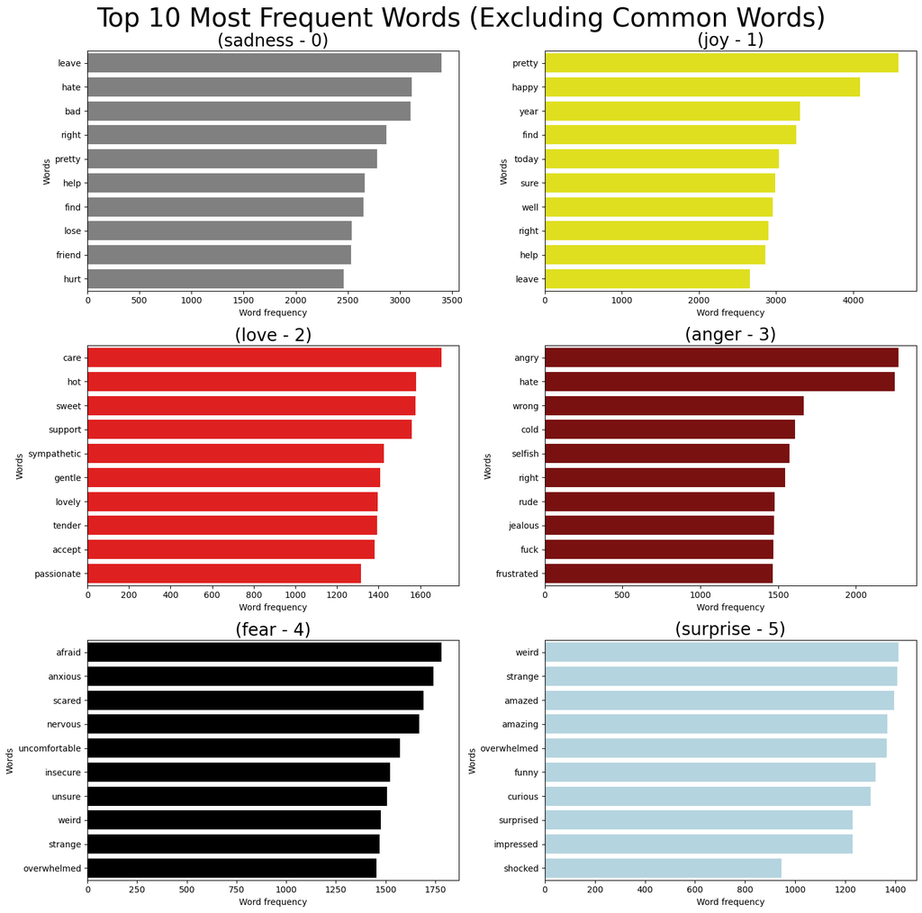

```python
# Grouping Data by the 'Label' column
grouped_data = Data.groupby('label')['preprocessed_text'].apply(lambda x: ' '.join(x.astype(str))).reset_index()

# Using CountVectorizer to count words - creating a token count matrix
vectorizer = CountVectorizer()
X = vectorizer.fit_transform(grouped_data['preprocessed_text'])

# Converting to DataFrame
word_counts = pd.DataFrame(X.toarray(), columns=vectorizer.get_feature_names_out(), index=grouped_data['label'])

# Sum of word occurrences in groups
word_occurrences_in_labels = word_counts.sum(axis=0)  # Total occurrences of each word in all groups

# Defining a Popularity Threshold (if the total occurrences of a word across all groups exceed 10,000, we remove it)
popularity_threshold = 10000
common_words_by_occurrence = word_occurrences_in_labels[word_occurrences_in_labels > popularity_threshold].index
word_counts_filtered = word_counts.drop(columns=common_words_by_occurrence)

# Identifying the 10 most frequent words for each group (after removing common words)
top_n = 10
top_words = {}
for label in word_counts_filtered.index:
    top_words[label] = word_counts_filtered.loc[label].sort_values(ascending=False).head(top_n)

# Creating Subplots
fig, axes = plt.subplots(3, 2, figsize=(15, 15))

# Transforming the 'top_words' list into an iterable list of pairs (label, words)
top_words_items = list(top_words.items())

for i, ax in enumerate(axes.flatten()):
    label, words = top_words_items[i]
    sns.barplot(
        x=words.values,
        y=words.index,
        ax=ax,
        hue=words.index,  # Using the 'hue' Variable to Assign Colors
        dodge=False,
        palette={word: colors[i] for word in words.index}
    )
    ax.set_title(titles[i], fontsize=20)
    ax.set_xlabel('Word frequency')
    ax.set_ylabel('Words')
    ax.legend_.remove()

fig.suptitle('Top 10 Most Frequent Words (Excluding Common Words)', fontsize=30)

plt.tight_layout()
plt.show()
```

Looking at the graphs showing the **top 10 most common words** (after excluding the most common words), we can observe that **each emotion has distinct keywords that can be clearly associated with it**.

Positive emotions, such as *joy* and *love*, are dominated by words associated with care, happiness, and positive relationships (e.g., pretty, happy, care).

In contrast, negative emotions like *sadness*, *anger*, and *fear* include words that reflect difficult experiences, such as loss, pain and conflict (e.g., leave, hate, afraid, wrong). These emotions are often associated with situations that cause stress and discomfort.

# **3. Preparing the Data**

We will remove the first column from our dataset - **'Unnamed: 0'**.

```python
Data = Data.drop(Data.columns[0], axis=1)
```

```python
Data.head()
```

|  | text | label | preprocessed_text |
| --- | --- | --- | --- |
| 0 | i just feel really helpless and heavy hearted | 4 | feel helpless heavy hearted |
| 1 | ive enjoyed being able to slouch about relax a... | 0 | ve enjoy able slouch relax unwind frankly need... |
| 2 | i gave up my internship with the dmrg and am f... | 4 | give internship dmrg feel distraught |
| 3 | i dont know i feel so lost | 0 | not know feel lost |
| 4 | i am a kindergarten teacher and i am thoroughl... | 4 | kindergarten teacher thoroughly weary job havi... |

## Tokenization

In our case, we will use three models: **SVM**, **LSTM**, and **Transformers**. Each of these models has its own specifications regarding the types of input data they handle best, so we will utilize different types of tokenization. For *SVM*, we will use **TF-IDF tokenization**; for *LSTM*, we will use **word indexing**; and for *Transformers*, we will use the **pre-trained TinyBERT model**.

### a) SVM

**TF-IDF tekonizer**

TF-IDF consists of two main components:

- **TF (Term Frequency)**: This is typically the number of occurrences of a word in a document divided by the total number of words in that document.

$$TF(t,d) = \frac{\text{The number of occurrences of the term } t \text{ in the document } d}{\text{Total number of words in document } d} $$

- **IDF (Inverse Document Frequency)** - This measures the uniqueness of terms. Words that appear in many documents have a lower IDF value, indicating they are less significant (as they are more common), while words that occur in fewer documents have a higher IDF value, suggesting they are more unique.

$$IDF(t,D) = log\left(\frac{\text{Total number of documents in set } D }{\text{Number of documents containing the term } t} \right) $$

**TF-IDF** is simply the **product of TF and IDF** for a given word in a document.

$$TF-IDF = TF(t,d) * IDF(t)$$

Words that frequently appear in a given document but rarely in others will have a high TF-IDF value, indicating they are more significant for that particular document.

```python
corpus = []
for x in range(len(Data)):
    corpus.append(Data.preprocessed_text[x])
corpus

vectorizer = TfidfVectorizer()
X_svm = vectorizer.fit_transform(corpus)
vectorizer.get_feature_names_out()
print(X_svm.shape)
```

```
(416809, 62382)
```

Next, **vectorizer.fit_transform(corpus)** transforms this list of texts into a sparse matrix **X_svm**, where each row corresponds to a document (text) from the corpus, each column corresponds to a word (or token), and each value in the matrix represents the importance of that word in the given document.

Finally, we display the size of the matrix.

### b) LSTM

**word indexing**

The **Tokenizer** object is created with a limit of *MAX_NB_WORDS* for the most frequently occurring words.

We obtain a token dictionary (*word_index*), which maps each word to a unique index.

```python
# Maximum number of words to use (most frequently occurring)
MAX_NB_WORDS = 30000
# Maximum number of words in each statement.
MAX_SEQUENCE_LENGTH = 30



tokenizer_lstm = Tokenizer(num_words = MAX_NB_WORDS)
tokenizer_lstm.fit_on_texts(Data['preprocessed_text'].values)
word_index = tokenizer_lstm.word_index
print('Found %s unique tokens.' %len(word_index))
```

```
Found 62405 unique tokens.
```

```python
# Converting Texts to Index Sequences
X = tokenizer_lstm.texts_to_sequences(Data['preprocessed_text'].values)
# Padding Sequences to MAX_SEQUENCE_LENGTH
X = pad_sequences(X, maxlen=MAX_SEQUENCE_LENGTH)
print('Dimensions of X:', X.shape)

Y = pd.get_dummies(Data['label']).values
print('Dimensions of Y:', Y.shape)
```

```
Dimensions of X: (416809, 30)
Dimensions of Y: (416809, 6)
```

**X** is a matrix with dimensions (*number of samples*, *MAX_SEQUENCE_LENGTH*). Each row represents a sequence of word indices corresponding to the words in a given statement. **If the statement is shorter than MAX_SEQUENCE_LENGTH, it is padded with zeros** at the beginning.

### c) Transformers

The **tokenizer converts text into numbers**, with each number representing a token that can be a word, part of a word, punctuation mark, or special tokens. The method of tokenizing the text is determined by the pre-trained model.

"*huawei-noah/TinyBERT_General_4L_312D*" is the version of the **TinyBERT model** used to retrieve the vocabulary from the pre-trained model, meaning the text will be tokenized in the same way as the BERT model.

```python
#tokenizer = AutoTokenizer.from_pretrained("bert-base-cased")
tokenizer = AutoTokenizer.from_pretrained("huawei-noah/TinyBERT_General_4L_312D")
```

#### Data Tokenization Function

```python
def tokenize_dataset(data):
    return tokenizer(data["preprocessed_text"],
                     max_length=30,
                     truncation=True,
                     padding="max_length")
```

Our data tokenization function will ensure that all texts have a consistent length of *30 tokens*.

We will use tokenization for transformers later after dividing the set into training and test sets.

# **4. Dataset Split and Undersampling**

## Undersampling

**Undersampling** is a technique that **reduces the size of the majority class** in a data set **to the size of the minority class**.

In our case, the smallest class is '*surprise*' (5). After splitting the dataset into training and testing sets, while maintaining the proportion of classes, we will randomly sample an equal number of observations from the remaining classes from the training set to obtain a balanced data set. Then, we will perform the analysis on both sets - the unbalanced and the balanced one.

## Splitting the dataset into training and testing sets

**80% of the data will be allocated to the training set, while the remaining 20% will be used for the testing set.**

The '*stratify*' parameter ensures that splitting the data into training and test sets preserves the proportions of label classes in the data. Whereas '*shuffle*' shuffles the data before splitting to ensure randomness.

### a) SVM

```python
X_train_svm, X_test_svm, y_train_svm, y_test_svm = train_test_split(
    X_svm,
    Data.label,
    stratify=Data.label,
    shuffle=True,
    test_size=0.2)

X_svm.shape
```

```
(416809, 62382)
```

```python
print("Dimensions of X_train_svm: ", X_train_svm.shape)
print("Dimensions of X_test_svm: ", X_test_svm.shape)
```

```
Dimensions of X_train_svm:  (333447, 62382)
Dimensions of X_test_svm:  (83362, 62382)
```

##### Undersampling

This code creates a *RandomUnderSampler* instance (*rus*) and applies it to the training dataset (*X_train_svm* and *y_train_svm*) to produce a balanced dataset (*X_resampled_svm* and *y_X_resampled_svm*).

```python
rus = RandomUnderSampler()
X_resampled_svm, y_X_resampled_svm = rus.fit_resample(X_train_svm, y_train_svm)
```

##### Balanced dataset

```python
X_train_svm_balanced, X_test_svm_balanced, y_train_svm_balanced, y_test_svm_balanced = train_test_split(
    X_resampled_svm,
    y_X_resampled_svm,
    stratify=y_X_resampled_svm,
    shuffle=True,
    test_size=0.2)

X_resampled_svm.shape
```

```
(71868, 62382)
```

```python
print("Dimensions of X_train_svm_balanced: ", X_train_svm_balanced.shape)
print("Dimensions of X_test_svm_balanced: ", X_test_svm_balanced.shape)
```

```
Dimensions of X_train_svm_balanced:  (57494, 62382)
Dimensions of X_test_svm_balanced:  (14374, 62382)
```

### b) LSTM

```python
X_train_lstm, X_test_lstm, y_train_lstm, y_test_lstm = train_test_split(
    X,
    Y,
    stratify=Y,
    shuffle=True,
    test_size = 0.2)

print("Dimensions of X_train_lstm: ", X_train_lstm.shape)
print("Dimensions of X_test_lstm: ", X_test_lstm.shape)
```

```
Dimensions of X_train_lstm:  (333447, 30)
Dimensions of X_test_lstm:  (83362, 30)
```

##### Undersampling

```python
X_resampled_lstm, y_X_resampled_lstm = rus.fit_resample(X_train_lstm, y_train_lstm)
```

##### Balanced dataset

```python
X_train_lstm_balanced, X_test_lstm_balanced, y_train_lstm_balanced, y_test_lstm_balanced = train_test_split(
    X_resampled_lstm,
    y_X_resampled_lstm,
    stratify = y_X_resampled_lstm,
    shuffle=True,
    test_size = 0.2)

print("Dimensions of X_train_lstm_balanced: ", X_train_lstm_balanced.shape)
print("Dimensions of X_test_lstm_balanced: ", X_test_lstm_balanced.shape)
```

```
Dimensions of X_train_lstm_balanced:  (57494, 30)
Dimensions of X_test_lstm_balanced:  (14374, 30)
```

### c) Transformery

```python
Data_t = Data.drop(Data.columns[0], axis=1)

train_data, test_data = train_test_split(
    Data_t,
    test_size=0.2,
    stratify=Data['label'],
    shuffle=True
)

print(f'The training set contains {len(train_data)} records.')
print(f'The testing set contains {len(test_data)} records.')
```

```
The training set contains 333447 records.
The testing set contains 83362 records.
```

##### Undersampling

```python
X_resampled_transformers, y_X_resampled_transformers = rus.fit_resample(train_data['preprocessed_text'].values.reshape(-1, 1), train_data['label'])
```

The **reshape(-1, 1)** method transforms a one-dimensional array into a two-dimensional matrix, which is required by **fit_resample()** since it expects the input data in a 2D format.

- The **-1** indicates that the number of rows will be automatically determined based on the number of examples.
- The **1** signifies that each row will contain a single column (e.g., one text per row).

```python
# Flattening X_resampled_transformers into a one-dimensional array.
X_resampled_transformers = X_resampled_transformers.flatten()

# Creating a new DataFrame with the resampled data.
resampled_train_data = pd.DataFrame({'preprocessed_text': X_resampled_transformers, 'label': y_X_resampled_transformers})
```

##### Balanced dataset

```python
train_data_balanced, test_data_balanced = train_test_split(
    resampled_train_data,
    test_size=0.2,
    stratify=resampled_train_data['label'],
    shuffle=True
)

print(f'The training set contains {len(train_data_balanced)} records.')
print(f'The testing set contains {len(test_data_balanced)} records.')
```

```
The training set contains 57494 records.
The testing set contains 14374 records.
```

# **5. Modeling**

## a) SVM (Support Vector Machines)

**Support Vector Machine (SVM)** is a supervised machine learning algorithm that classifies data by finding the optimal line or hyperplane that maximizes the margin between different classes in an N-dimensional space.

```python
classifier = LinearSVC(class_weight='balanced', dual=False)
classifier.fit(X_train_svm, y_train_svm) #Fitting the model to the training data
y_pred_class = classifier.predict(X_test_svm)
y_pred_class2 = classifier.predict(X_train_svm)

# Collecting metrics
acc_train_svm = round(metrics.accuracy_score(y_train_svm, y_pred_class2),4)
acc_test_svm = round(metrics.accuracy_score(y_test_svm, y_pred_class),4)

#print("Accuracy (train set): ", round(metrics.accuracy_score(y_train_svm, y_pred_class2),4))
print("Accuracy (test set): ", round(metrics.accuracy_score(y_test_svm, y_pred_class),4))
```

```
Accuracy (test set):  0.8835
```

The **SVM** (*Support Vector Machine*) model achieved an accuracy of **0.8835** on the **test set**. This means that the model correctly classified about 88.35% of the samples in the test set.

However, this is an imbalanced dataset, meaning the data is unevenly distributed across the classes, which may affect the result. The majority of the samples belong to classes 1 and 0, while class 5 has the fewest samples. This imbalance can lead to better model fit for more represented classes and worse for the less frequent ones. Therefore, we will also check other metrics like the **F1-score** and visualize our results using a **Confusion Matrix**.

#### Confusion Matrix (test set)

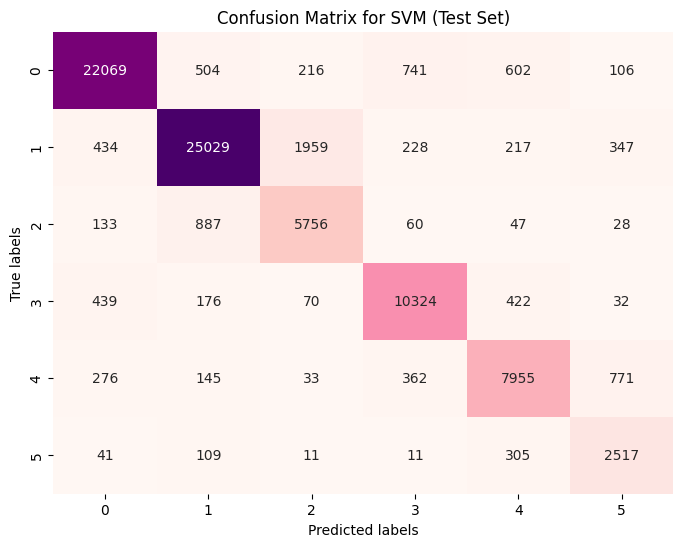

```python
cm = confusion_matrix(y_test_svm, y_pred_class)


plt.figure(figsize=(8, 6))
sns.heatmap(cm, annot=True, fmt='d', cmap='RdPu', cbar=False)
plt.xlabel('Predicted labels')
plt.ylabel('True labels')
plt.title('Confusion Matrix for SVM (Test Set)')
plt.show()
```

**Y-axis (True Labels)** – shows the actual classes to which the test data belongs.

**X-axis (Predicted Labels)** – shows the classes predicted by the model.

The **diagonal values** are correctly classified examples. The remaining values off the diagonal are classification errors, i.e. examples that the model predicted incorrectly. For example, cell(1,2) = 1959 means that 1959 examples of class 1 were incorrectly classified as class 2.

Classes 0 and 1 have the highest number of correct predictions, which is also due to their larger representation in the dataset. Classes 2, 3, 4, and 5, being less frequent, have lower values along the diagonal.

The largest model misclassifications occur between classes 1 and 2 and 4 and 5. Class 1(*joy*) is sometimes predicted as class 2(*love*) and vice versa, and class 4(*fear*) is sometimes predicted as class 5(*surprise*), which may suggest some similarities between these classes.

```python
print(classification_report(y_test_svm, y_pred_class))
```

```
              precision    recall  f1-score   support

           0       0.94      0.91      0.93     24238
           1       0.93      0.89      0.91     28214
           2       0.72      0.83      0.77      6911
           3       0.88      0.90      0.89     11463
           4       0.83      0.83      0.83      9542
           5       0.66      0.84      0.74      2994

    accuracy                           0.88     83362
   macro avg       0.83      0.87      0.85     83362
weighted avg       0.89      0.88      0.89     83362
```

**Classes** 0 and 1 (**dominant in the data**) have **the highest F1-scores** (0.93 and 0.91), suggesting that the model performs well in classifying the most frequently occurring classes.

Classes 2 and 5, which are less frequent, have lower F1-scores of 0.77 and 0.74, respectively.

```python
f1_train_svm = round(f1_score(y_train_svm, y_pred_class2, average='weighted'),4)
f1_test_svm = round(f1_score(y_test_svm, y_pred_class, average='weighted'),4)
print("F1-score (Test set):", f1_test_svm)
```

```
F1-score (Test set): 0.8854
```

The **weighted F1-score value** on the **test set** is **0.8854**, which suggests that the model achieves a good balance between precision and recall, taking into account the frequency of the classes.

We will prepare **new sample texts** to test our models.

```python
# New Sentences for Prediction
new_sentences0 = [
    'i feel very discouraged and disappointed', #0
    'i feel so empty inside...', #0
    'i feel lucky to have so many nice people in my live', #1
    'I want to give him everything because loving him gives me everything.', #2
    'i was feeling romantic', #2
    'i feel so mad and confused again', #3
    'I went out for a walk at night on my own I lost my way and spent several minutes in the dark alley', #4
    'i got scared when i saw that i had to go through a dark alley', #4
    'i just feel really helpless and heavy hearted', #4
    'I just watched the documentary and Im impressed that he was such a great man', #5
    'i feel amazing about using only natural mostly', #5
    'i am feeling pretty impressed' #5
]

# Transform the sentences
new_sentences = [preprocess(sentence) for sentence in new_sentences0]

# Transforming new sentences into TF-IDF Vectors
new_sentences_tfidf = vectorizer.transform(new_sentences)

# Predicting labels for new sentences
new_predictions = classifier.predict(new_sentences_tfidf)

# List of Labels
labels = ['0 - sadness', '1 - joy', '2 - love', '3 - anger', '4 - fear', '5 - surprise']

# Converting numerical labels to textual labels
new_predictions_labels = [labels[prediction] for prediction in new_predictions]

# Display the predicted labels with their textual descriptions.
for sentence, prediction_label in zip(new_sentences0, new_predictions_labels):
    print(f"Sentence: '{sentence}'")
    print(f"Predicted emotion: {prediction_label}\n")
```

```
Sentence: 'i feel very discouraged and disappointed'
Predicted emotion: 0 - sadness

Sentence: 'i feel so empty inside...'
Predicted emotion: 0 - sadness

Sentence: 'i feel lucky to have so many nice people in my live'
Predicted emotion: 1 - joy

Sentence: 'I want to give him everything because loving him gives me everything.'
Predicted emotion: 2 - love

Sentence: 'i was feeling romantic'
Predicted emotion: 2 - love

Sentence: 'i feel so mad and confused again'
Predicted emotion: 3 - anger

Sentence: 'I went out for a walk at night on my own I lost my way and spent several minutes in the dark alley'
Predicted emotion: 4 - fear

Sentence: 'i got scared when i saw that i had to go through a dark alley'
Predicted emotion: 4 - fear

Sentence: 'i just feel really helpless and heavy hearted'
Predicted emotion: 4 - fear

Sentence: 'I just watched the documentary and Im impressed that he was such a great man'
Predicted emotion: 5 - surprise

Sentence: 'i feel amazing about using only natural mostly'
Predicted emotion: 5 - surprise

Sentence: 'i am feeling pretty impressed'
Predicted emotion: 5 - surprise
```

The model effectively identifies emotions in texts, which proves its high performance in the given task.

##### Balanced dataset

```python
classifier_balanced = LinearSVC(class_weight='balanced', dual=False)
classifier_balanced.fit(X_train_svm_balanced, y_train_svm_balanced) #dopasowujemy model do danych treningowych
y_pred_class_balanced = classifier_balanced.predict(X_test_svm_balanced)
y_pred_class2_balanced = classifier_balanced.predict(X_train_svm_balanced)

# Collecting metrics
acc_train_svm_balanced = round(metrics.accuracy_score(y_train_svm_balanced, y_pred_class2_balanced),4)
acc_test_svm_balanced = round(metrics.accuracy_score(y_test_svm_balanced, y_pred_class_balanced),4)

#print("Accuracy (Train set): ", round(metrics.accuracy_score(y_train_svm_balanced, y_pred_class2_balanced),4))
print("Accuracy (Test set): ", round(metrics.accuracy_score(y_test_svm_balanced, y_pred_class_balanced),4))
```

```
Accuracy (Test set):  0.8911
```

The **SVM model** achieved an **accuracy of 0.8911** (**Test set**) on the **balanced dataset**, which is better than the accuracy on the unbalanced dataset (0.8835). This means the model correctly classified around 89.11% of the test set samples. Both results are quite high.

#### Confusion Matrix (Test set)

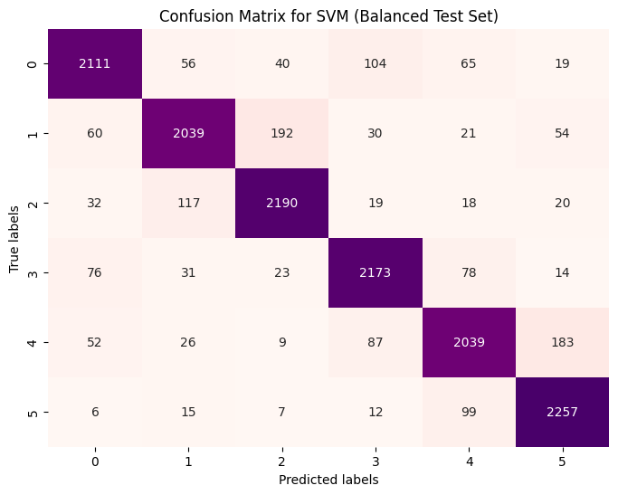

```python
cm = confusion_matrix(y_test_svm_balanced, y_pred_class_balanced)


plt.figure(figsize=(8, 6))
sns.heatmap(cm, annot=True, fmt='d', cmap='RdPu', cbar=False)
plt.xlabel('Predicted labels')
plt.ylabel('True labels')
plt.title('Confusion Matrix for SVM (Balanced Test Set)')
plt.show()
```

On the **balanced dataset**, the Confusion Matrix looks quite different on the **test set**. The **diagonal values** are quite high and close to each other. Most examples are classified correctly, indicating that the model performs well.

However, there are some misclassifications observed. For instance, class 1 (*joy*) is sometimes predicted as class 2 (*love*), class 0 (*sadness*) as class 3 (*anger*), or class 4 (*fear*) as class 5 (*surprise*).

The largest errors seem to occur between classes 1 (*joy*) and 2 (*love*), as well as 4 (*fear*) and 5 (*surprise*), suggesting some similarities between these classes that are challenging for the model to distinguish.

```python
print(classification_report(y_test_svm_balanced, y_pred_class_balanced))
```

```
              precision    recall  f1-score   support

           0       0.90      0.88      0.89      2395
           1       0.89      0.85      0.87      2396
           2       0.89      0.91      0.90      2396
           3       0.90      0.91      0.90      2395
           4       0.88      0.85      0.86      2396
           5       0.89      0.94      0.91      2396

    accuracy                           0.89     14374
   macro avg       0.89      0.89      0.89     14374
weighted avg       0.89      0.89      0.89     14374
```

We notice that the **F1-scores** have also changed, and now all classes have similar values. Previously, the lowest score was 0.74, but now the lowest value is 0.86.

```python
f1_train_svm_balanced = round(f1_score(y_train_svm_balanced, y_pred_class2_balanced, average='weighted'),4)
f1_test_svm_balanced = round(f1_score(y_test_svm_balanced, y_pred_class_balanced, average='weighted'),4)
print("F1-score (weighted):", f1_test_svm_balanced)
```

```
F1-score (weighted): 0.8908
```

The **weighted F1-score** on the **balanced test set** is **0.8908**, which is slightly higher than on the unbalanced test set (0.8854).

```python
# Predicting labels for new sentences
new_predictions = classifier_balanced.predict(new_sentences_tfidf)

# Converting numerical labels to textual labels
new_predictions_labels = [labels[prediction] for prediction in new_predictions]

# Display the predicted labels with their textual descriptions.
for sentence, prediction_label in zip(new_sentences0, new_predictions_labels):
    print(f"Sentence: '{sentence}'")
    print(f"Predicted emotion: {prediction_label}\n")
```

```
Sentence: 'i feel very discouraged and disappointed'
Predicted emotion: 0 - sadness

Sentence: 'i feel so empty inside...'
Predicted emotion: 0 - sadness

Sentence: 'i feel lucky to have so many nice people in my live'
Predicted emotion: 1 - joy

Sentence: 'I want to give him everything because loving him gives me everything.'
Predicted emotion: 2 - love

Sentence: 'i was feeling romantic'
Predicted emotion: 2 - love

Sentence: 'i feel so mad and confused again'
Predicted emotion: 3 - anger

Sentence: 'I went out for a walk at night on my own I lost my way and spent several minutes in the dark alley'
Predicted emotion: 0 - sadness

Sentence: 'i got scared when i saw that i had to go through a dark alley'
Predicted emotion: 4 - fear

Sentence: 'i just feel really helpless and heavy hearted'
Predicted emotion: 4 - fear

Sentence: 'I just watched the documentary and Im impressed that he was such a great man'
Predicted emotion: 5 - surprise

Sentence: 'i feel amazing about using only natural mostly'
Predicted emotion: 5 - surprise

Sentence: 'i am feeling pretty impressed'
Predicted emotion: 5 - surprise
```

We again observe that the model mostly performed well in classifying the emotions in the given sentences, but it made one mistake.

The sentence "I went out for a walk at night on my own I lost my way and spent several minutes in the dark alley" might seem to express the emotion of *fear*, but the model assigned it to the category of *sadness* (emotion 0). However, this sentence is not entirely unambiguous. Depending on individual interpretation, it could also be understood as expressing sadness.

The model trained on the **balanced dataset** shows more **consistent metrics** across the different classes, particularly noticeable with the F1-score.

A **balanced dataset** ensures the model **treats all classes more evenly**, whereas a model trained on an **imbalanced dataset tends to favor the more frequent classes**, leading to worse performance for the less frequent ones.

However, on both the balanced and imbalanced datasets, the model generally classifies emotions quite well, accurately assigning them to the correct categories. Nonetheless, it is not perfect and makes minor classification errors.

## b) LSTM (Long short-term memory)

**Long short-term memory (LSTM)** is a type of **recurrent neural network (RNN)** aimed at dealing with the vanishing gradient problem present in traditional RNNs.

A common **LSTM unit** consists of a **cell**, an **input gate**, an **output gate**, and a **forget gate**.

```python
EMBEDDING_DIM = 64

model = Sequential()
model.add(Embedding(MAX_NB_WORDS, EMBEDDING_DIM, input_length=X.shape[1]))
model.add(SpatialDropout1D(0.3))
model.add(LSTM(64, dropout=0.3, recurrent_dropout=0.3))
model.add(Dense(6, activation='softmax'))
model.compile(loss='categorical_crossentropy', optimizer='adam', metrics=['accuracy'])
```

The model will be trained for **6 epochs**, so the entire training set will be processed by the model six times.

The training data will be divided into **batches of 100 samples**.

```python
epochs = 6
batch_size = 100

history = model.fit(X_train_lstm, y_train_lstm, epochs=epochs, batch_size=batch_size, validation_data=(X_test_lstm, y_test_lstm))
```

```
3335/3335 ━━━━━━━━━━━━━━━━━━━━ 135s 39ms/step - accuracy: 0.7630 - loss: 0.6254 - val_accuracy: 0.9260 - val_loss: 0.1406
3335/3335 ━━━━━━━━━━━━━━━━━━━━ 130s 39ms/step - accuracy: 0.9277 - loss: 0.1418 - val_accuracy: 0.9253 - val_loss: 0.1281
3335/3335 ━━━━━━━━━━━━━━━━━━━━ 131s 39ms/step - accuracy: 0.9308 - loss: 0.1279 - val_accuracy: 0.9252 - val_loss: 0.1264
3335/3335 ━━━━━━━━━━━━━━━━━━━━ 132s 39ms/step - accuracy: 0.9318 - loss: 0.1214 - val_accuracy: 0.9242 - val_loss: 0.1255
3335/3335 ━━━━━━━━━━━━━━━━━━━━ 131s 39ms/step - accuracy: 0.9340 - loss: 0.1161 - val_accuracy: 0.9220 - val_loss: 0.1249
3335/3335 ━━━━━━━━━━━━━━━━━━━━ 131s 39ms/step - accuracy: 0.9343 - loss: 0.1134 - val_accuracy: 0.9252 - val_loss: 0.1258
```

The **training accuracy** increased from 0.7630 to 0.9343 , which means that the model is learning very quickly and improving its performance on the training set. The **accuracy** on the **validation set** remains relatively stable. The lack of further improvement in *val_accuracy* suggests that the model has reached a certain generalization limit, meaning it is not significantly improving on new data.

The **training loss** decreased from 0.6254 to 0.1134, which shows that the model is gradually minimizing the prediction error. The **validation loss** also decreases at the beginning, but stabilizes at around 0.1260. The stability in validation loss suggests that the model is not overfitting.

#### Metrics for the **train set**

```python
accr_train_lstm = model.evaluate(X_train_lstm, y_train_lstm)
print('Training results\n  Loss: {:0.4f}\n  Accuracy: {:0.4f}'.format(accr_train_lstm[0], accr_train_lstm[1]))
acc_train_lstm = round(accr_train_lstm[1], 4)
```

```
10421/10421 ━━━━━━━━━━━━━━━━━━━━ 70s 7ms/step - accuracy: 0.9392 - loss: 0.1019
Training results
  Loss: 0.1026
  Accuracy: 0.9388
```

The **train accuracy** is **0.9388**, and the **train loss** is **0.1026**.

```python
y_train_pred = model.predict(X_train_lstm, batch_size=batch_size)

# Converting predictions to class labels
y_train_pred_classes = np.argmax(y_train_pred, axis=1)
y_train_true = np.argmax(y_train_lstm, axis=1)

# F1-score
f1_train_lstm = round(f1_score(y_train_true, y_train_pred_classes, average='weighted'),4)
print("F1-score (train set):", f1_train_lstm)
```

```
3335/3335 ━━━━━━━━━━━━━━━━━━━━ 45s 13ms/step
F1-score (train set): 0.9394
```

#### Metrics for the **test set**

```python
accr_test_lstm = model.evaluate(X_test_lstm,y_test_lstm)
print('Test results\n  Loss: {:0.4f}\n  Accuracy: {:0.4f}'.format(accr_test_lstm[0],accr_test_lstm[1]))
acc_test_lstm = round(accr_test_lstm[1], 4)
```

```
2606/2606 ━━━━━━━━━━━━━━━━━━━━ 17s 7ms/step - accuracy: 0.9260 - loss: 0.1232
Test results
  Loss: 0.1258
  Accuracy: 0.9252
```

**Test accuracy** is **0.9252**, and **test loss** is **0.1258**, which shows that the model performs well on the test data.

```python
y_pred = model.predict(X_test_lstm, batch_size=batch_size)

# Converting predictions to class labels
y_pred_classes = np.argmax(y_pred, axis=1)
y_true = np.argmax(y_test_lstm, axis=1)

# F1-score
f1_test_lstm = round(f1_score(y_true, y_pred_classes, average='weighted'), 4)
print("F1-score:", f1_test_lstm)
```

```
834/834 ━━━━━━━━━━━━━━━━━━━━ 11s 13ms/step
F1-score: 0.926
```

The **F1-score** is a more reliable metric here since the dataset is imbalanced. We also observe its quite high value – **0.9260**.

#### Confusion Matrix (Test Set)

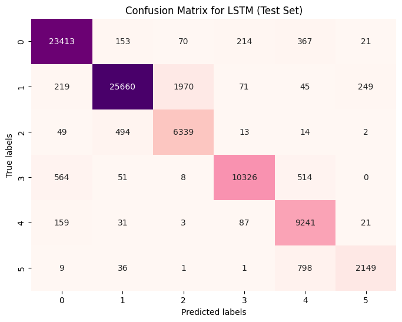

```python
cm = confusion_matrix(y_true, y_pred_classes)


plt.figure(figsize=(8,6))
sns.heatmap(cm, annot=True, fmt='d', cmap='RdPu', cbar=False)
plt.xlabel('Predicted labels')
plt.ylabel('True labels')
plt.title('Confusion Matrix for LSTM (Test Set)')
plt.show()
```

Similar to the SVM model for the imbalanced dataset, class 0 and class 1, which are the most frequent, have the highest number of correct predictions. Classes 2, 3, 4, and 5, which are less represented, show lower values along the diagonal.

The biggest misclassifications occur again between classes, such as class 1 and 2, and between class 5 and 4. Additionally, class 0 (*sadness*) is sometimes predicted as class 3 (*anger*) or class 4 (*fear*) and vice versa.

The incorrect predictions may suggest certain similarities between these classes.

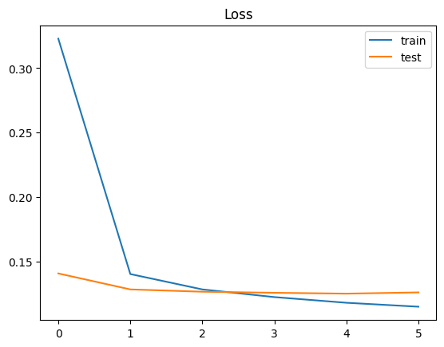

```python
plt.title('Loss')
plt.plot(history.history['loss'], label='train')
plt.plot(history.history['val_loss'], label='test')
plt.legend()
plt.show();
```

The rapid decrease in **loss** on the **training dataset** *(blue line)* suggests that the model is quickly adapting to the data.

The **loss** on the **test dataset** *(orange line)* remains relatively stable, indicating that the model is probably not overfitting and generalizes well.

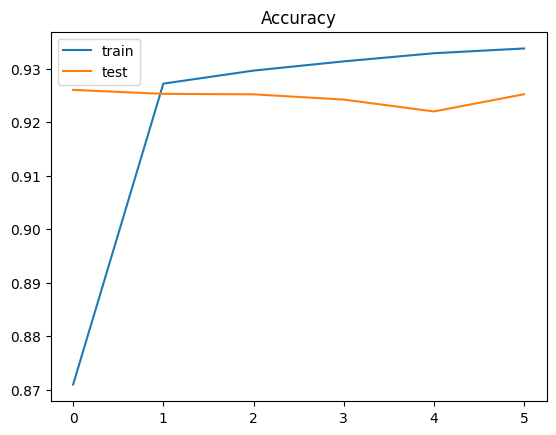

```python
plt.title('Accuracy')
plt.plot(history.history['accuracy'], label='train')
plt.plot(history.history['val_accuracy'], label='test')
plt.legend()
plt.show();
```

The model's **accuracy** for **training data** *(blue line)* increases rapidly already in the first epoch. In subsequent epochs, the accuracy increases slightly, but the changes are minimal.

The model's **accuracy** for the **validation (test) data** *(orange line)* starts at a higher value than the training data (around 0.925) and remains at a similar level.

The model learns quickly, achieving a high level of accuracy on the training data and a stable, high accuracy on the test data.

```python
# Tokenization of all new sentences
seq = tokenizer_lstm.texts_to_sequences(new_sentences)
padded = pad_sequences(seq, maxlen=MAX_SEQUENCE_LENGTH)

# Predictions
predictions = model.predict(padded)

labels = ['0 - sadness', '1 - joy', '2 - love', '3 - anger', '4 - fear', '5 - surprise']

# Results
for i, pred in enumerate(predictions):
    print(f"Sentence: {new_sentences0[i]}")
    print(f"Predicted emotion: {labels[np.argmax(pred)]}\n")
```

```
1/1 ━━━━━━━━━━━━━━━━━━━━ 0s 27ms/step
Sentence: i feel very discouraged and disappointed
Predicted emotion: 0 - sadness

Sentence: i feel so empty inside...
Predicted emotion: 0 - sadness

Sentence: i feel lucky to have so many nice people in my live
Predicted emotion: 1 - joy

Sentence: I want to give him everything because loving him gives me everything.
Predicted emotion: 1 - joy

Sentence: i was feeling romantic
Predicted emotion: 2 - love

Sentence: i feel so mad and confused again
Predicted emotion: 3 - anger

Sentence: I went out for a walk at night on my own I lost my way and spent several minutes in the dark alley
Predicted emotion: 4 - fear

Sentence: i got scared when i saw that i had to go through a dark alley
Predicted emotion: 4 - fear

Sentence: i just feel really helpless and heavy hearted
Predicted emotion: 4 - fear

Sentence: I just watched the documentary and Im impressed that he was such a great man
Predicted emotion: 3 - anger

Sentence: i feel amazing about using only natural mostly
Predicted emotion: 5 - surprise

Sentence: i am feeling pretty impressed
Predicted emotion: 5 - surprise
```

We notice that the model performs fairly well, although not perfectly, in classifying the data. Let’s examine cases where the model misclassified the emotions:

'I want to give him everything because loving him gives me everything.' The model's prediction is (1 - joy), but this sentence expresses positive emotions related to love, suggesting that it should be classified as (2 - love).

This confirms what we observed in the Confusion Matrix, where class 2 (*love*) is sometimes incorrectly predicted as class 1 (*joy*).

Additionally, the sentence 'I just watched the documentary and Im impressed that he was such a great man' was predicted as emotion (3 - anger). However, this sentence expresses admiration, which seems closer to emotion (5 - surprise).

##### Balanced dataset

```python
model = Sequential()
model.add(Embedding(MAX_NB_WORDS, EMBEDDING_DIM, input_length=X.shape[1]))
model.add(SpatialDropout1D(0.3))
model.add(LSTM(64, dropout=0.3, recurrent_dropout=0.3))
model.add(Dense(6, activation='softmax'))
model.compile(loss='categorical_crossentropy', optimizer='adam', metrics=['accuracy'])
```

```python
epochs = 6
batch_size = 100

history_balanced = model.fit(X_train_lstm_balanced, y_train_lstm_balanced, epochs=epochs, batch_size=batch_size, validation_data=(X_test_lstm_balanced, y_test_lstm_balanced))
```

```
575/575 ━━━━━━━━━━━━━━━━━━━━ 26s 40ms/step - accuracy: 0.5012 - loss: 1.3044 - val_accuracy: 0.9074 - val_loss: 0.2837
575/575 ━━━━━━━━━━━━━━━━━━━━ 41s 39ms/step - accuracy: 0.9075 - loss: 0.2745 - val_accuracy: 0.9255 - val_loss: 0.2117
575/575 ━━━━━━━━━━━━━━━━━━━━ 22s 39ms/step - accuracy: 0.9306 - loss: 0.1921 - val_accuracy: 0.9267 - val_loss: 0.1999
575/575 ━━━━━━━━━━━━━━━━━━━━ 22s 38ms/step - accuracy: 0.9399 - loss: 0.1588 - val_accuracy: 0.9261 - val_loss: 0.1963
575/575 ━━━━━━━━━━━━━━━━━━━━ 23s 39ms/step - accuracy: 0.9447 - loss: 0.1423 - val_accuracy: 0.9245 - val_loss: 0.2002
575/575 ━━━━━━━━━━━━━━━━━━━━ 23s 40ms/step - accuracy: 0.9479 - loss: 0.1298 - val_accuracy: 0.9244 - val_loss: 0.2026
```

For the **balanced dataset**, the **training accuracy** increased from 0.5012 to 0.9479, indicating that the model improved its classification skills with training. The **validation set accuracy** stays fairly consistent.

The **training loss** decreased from 1.3044 to 0.1298, suggesting that the model is fitting better to the training data. The **validation loss** also decreases at the beginning, but stabilizes at around 0.2. The stability in validation loss suggests that the model is not overfitting.

#### Metrics for the **train set**

```python
accr_train_lstm_balanced = model.evaluate(X_train_lstm, y_train_lstm)
print('Training results\n  Loss: {:0.4f}\n  Accuracy: {:0.4f}'.format(accr_train_lstm_balanced[0], accr_train_lstm_balanced[1]))
acc_train_lstm_balanced = round(accr_train_lstm_balanced[1], 4)
```

```
10421/10421 ━━━━━━━━━━━━━━━━━━━━ 71s 7ms/step - accuracy: 0.9186 - loss: 0.2184
Training results
  Loss: 0.2201
  Accuracy: 0.9177
```

The **train accuracy** is **0.9177**, and the **train loss** is **0.2201**.

```python
y_train_pred_balanced = model.predict(X_train_lstm_balanced, batch_size=batch_size)

# Converting predictions to class labels
y_train_pred_classes_balanced = np.argmax(y_train_pred_balanced, axis=1)
y_train_true_balanced = np.argmax(y_train_lstm_balanced, axis=1)

# F1-score
f1_train_lstm_balanced = round(f1_score(y_train_true_balanced, y_train_pred_classes_balanced, average='weighted'),4)
print("F1-score (train set):", f1_train_lstm_balanced)
```

```
575/575 ━━━━━━━━━━━━━━━━━━━━ 8s 14ms/step
F1-score (train set): 0.9597
```

#### Metrics for the **test set**

```python
accr_test_lstm_balanced  = model.evaluate(X_test_lstm_balanced,y_test_lstm_balanced)
print('Test results\n  Loss: {:0.4f}\n  Accuracy: {:0.4f}'.format(accr_test_lstm_balanced[0],accr_test_lstm_balanced[1]))
acc_test_lstm_balanced = round(accr_test_lstm_balanced[1], 4)
```

```
450/450 ━━━━━━━━━━━━━━━━━━━━ 3s 7ms/step - accuracy: 0.9255 - loss: 0.2009
Test results
  Loss: 0.2026
  Accuracy: 0.9244
```

The **test accuracy** is **0.9244**, and the **test loss** is **0.2026**, indicating that the model performs well on the test data.

```python
y_pred_balanced = model.predict(X_test_lstm_balanced, batch_size=batch_size)


# Converting predictions to class labels
y_pred_classes_balanced = np.argmax(y_pred_balanced, axis=1)
y_true_balanced = np.argmax(y_test_lstm_balanced, axis=1)

# F1-score
f1_test_lstm_balanced = round(f1_score(y_true_balanced, y_pred_classes_balanced, average='weighted'),4)
print("F1-score:", f1_test_lstm_balanced)
```

```
144/144 ━━━━━━━━━━━━━━━━━━━━ 2s 13ms/step
F1-score: 0.9243
```

The **F1-score** is also quite high, at **0.9243**.

#### Confusion Matrix (Test Set)

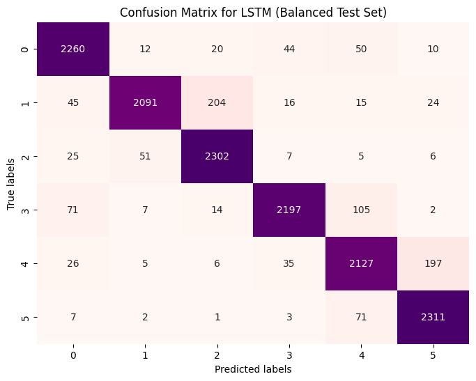

```python
cm = confusion_matrix(y_true_balanced, y_pred_classes_balanced)


plt.figure(figsize=(8,6))
sns.heatmap(cm, annot=True, fmt='d', cmap='RdPu', cbar=False)
plt.xlabel('Predicted labels')
plt.ylabel('True labels')
plt.title('Confusion Matrix for LSTM (Balanced Test Set)')
plt.show()
```

On the **balanced test set**, the Confusion Matrix looks significantly better. The diagonal values are quite high and similar to each other. Most examples are classified correctly, indicating that the model performs well.

However, there are still some mistakes, such as class 1 (*joy*) sometimes being predicted as class 2 (*love*), class 4 (*fear*) as class 5 (*surprise*), or class 3 (*anger*) as class 4 (*fear*).

We can observe that the largest classification errors still occur between the same classes. This suggests that there are some similarities between these classes that the model finds difficult to distinguish clearly.

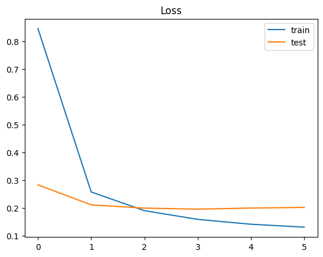

```python
plt.title('Loss')
plt.plot(history_balanced.history['loss'], label='train')
plt.plot(history_balanced.history['val_loss'], label='test')
plt.legend()
plt.show();
```

The model quickly adapts to the data, as can be seen from the rapid decrease in the **loss** on the **training set** *(blue line)*.

The **loss** on the **test set** decreases slightly, indicating that the model is likely not overfitting and generalizes well.

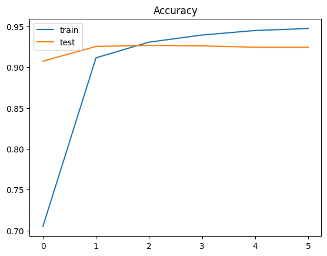

```python
plt.title('Accuracy')
plt.plot(history_balanced.history['accuracy'], label='train')
plt.plot(history_balanced.history['val_accuracy'], label='test')
plt.legend()
plt.show();
```

The model's **accuracy** for the **training data** (*blue line*) increases rapidly, reaching over 0.90 and then 0.94.

The **accuracy** for the **validation (test) data** starts at a higher value than the training data (around 0.90) and rises slightly.

The model learns quickly, achieving a high level of accuracy on the training data and a fairly stable, high accuracy on the test data.

```python
# Predictions
predictions = model.predict(padded)

# Results
for i, pred in enumerate(predictions):
    print(f"Sentence: {new_sentences0[i]}")
    print(f"Predicted emotion: {labels[np.argmax(pred)]}\n")
```

```
1/1 ━━━━━━━━━━━━━━━━━━━━ 0s 28ms/step
Sentence: i feel very discouraged and disappointed
Predicted emotion: 0 - sadness

Sentence: i feel so empty inside...
Predicted emotion: 0 - sadness

Sentence: i feel lucky to have so many nice people in my live
Predicted emotion: 1 - joy

Sentence: I want to give him everything because loving him gives me everything.
Predicted emotion: 3 - anger

Sentence: i was feeling romantic
Predicted emotion: 2 - love

Sentence: i feel so mad and confused again
Predicted emotion: 3 - anger

Sentence: I went out for a walk at night on my own I lost my way and spent several minutes in the dark alley
Predicted emotion: 4 - fear

Sentence: i got scared when i saw that i had to go through a dark alley
Predicted emotion: 4 - fear

Sentence: i just feel really helpless and heavy hearted
Predicted emotion: 4 - fear

Sentence: I just watched the documentary and Im impressed that he was such a great man
Predicted emotion: 5 - surprise

Sentence: i feel amazing about using only natural mostly
Predicted emotion: 5 - surprise

Sentence: i am feeling pretty impressed
Predicted emotion: 5 - surprise
```

In this case, the model also performs very well in classification, but one error occurred:

The sentence 'I want to give him everything because loving him gives me everything.' was predicted as (3 - anger), but in reality, this sentence expresses a positive emotion, most closely associated with (2 - love).

## c) Transformers

### Conversion of DataFrame to Hugging Face Arrow Dataset

**Hugging Face Dataset** is optimized for working with large datasets, allowing for fast data operations and memory efficiency.

The length of the Hugging Face dataset is the same as the number of records in the pandas DataFrame.

```python
hg_train_data = Dataset.from_pandas(train_data)
hg_test_data = Dataset.from_pandas(test_data)


#balanced
hg_train_data_balanced = Dataset.from_pandas(train_data_balanced)
hg_test_data_balanced = Dataset.from_pandas(test_data_balanced)
```

```python
# Dimensions
print(f'Size of hg_train_data: {len(hg_train_data)}.\n')
print(f'Size of hg_train_data_balanced: {len(hg_train_data_balanced)}.\n')

# Checking the First Record
hg_train_data[0]
#hg_train_data_balanced[0]
```

```
Size of hg_train_data: 333447.

Size of hg_train_data_balanced: 57494.
```

```
{'label': 0,
 'preprocessed_text': 'don t feel particularly numb depressed line stick',
 '__index_level_0__': 286413}
```

#### Tokenization

```python
dataset_train = hg_train_data.map(tokenize_dataset)
dataset_test = hg_test_data.map(tokenize_dataset)

#balanced
dataset_train_balanced = hg_train_data_balanced.map(tokenize_dataset)
dataset_test_balanced = hg_test_data_balanced.map(tokenize_dataset)
```

### Loading a pre-trained model.

*huawei-noah/TinyBERT_General_4L_312D* is the name of the pre-trained model (TinyBERT version).

*num_labels* indicates the number of classes. Our dataset has six classes, so num_labels=6.

```python
sys.stdout = open(os.devnull, 'w')
sys.stderr = open(os.devnull, 'w')


#model = AutoModelForSequenceClassification.from_pretrained("bert-base-cased", num_labels=6)
#model = AutoModelForSequenceClassification.from_pretrained("distilbert-base-cased", num_labels=6)
model = AutoModelForSequenceClassification.from_pretrained("huawei-noah/TinyBERT_General_4L_312D", num_labels=6)
model_balanced = AutoModelForSequenceClassification.from_pretrained("huawei-noah/TinyBERT_General_4L_312D", num_labels=6)

sys.stdout = original_stdout
sys.stderr = original_stderr
```

#### Training arguments configuration

**Hugging Face** provides many parameters for *TrainingArguments*, offering great flexibility in tuning the transfer learning model.

- *output_dir* is the directory where model checkpoints and predictions are saved.
- *logging_dir* is the directory where logs are saved.
- *logging_strategy* is the strategy for logging training information.
  - '*no*' means no logging during training.
  - '*epoch*' means logging at the end of each epoch.
  - '*steps*' means logging at the end of every logging_steps.
- *logging_steps* is the number of steps between two logs. The default value is 500.
- *num_train_epochs* is the total number of training epochs. The default value is 3.
- *per_device_train_batch_size* is the batch size per GPU/TPU/CPU core for training. The default value is 8.
- *per_device_eval_batch_size* is the batch size per GPU/TPU/CPU core for evaluation. The default value is 8.
- *learning_rate* is the initial learning rate for the AdamW optimizer. The default value is 5e-5.
- *seed* is used for reproducibility.
- *save_strategy* is the strategy for saving checkpoints during training.
  - '*no*' means do not save during training.
  - '*epoch*' means save at the end of each epoch.
  - '*steps*' means save at the end of every save_steps. 'steps' is the default value.
- *save_steps* is the number of steps before saving two checkpoints. The default value is 500.
- *evaluation_strategy* is the strategy for evaluation during training. It is useful for monitoring the model's performance while fine-tuning.
  - '*no*' means no evaluation during training.
  - '*epoch*' means evaluation at the end of each epoch, and the evaluation results will be printed at the end of each epoch.
  - '*steps*' means evaluation and reporting at the end of every eval_steps. 'no' is the default value.
- *eval_steps* is the number of steps between two evaluations if evaluation_strategy='steps'. By default, it takes the same value as logging_steps if not set.
- *load_best_model_at_end=True* indicates that the best model will be loaded at the end of training. By default, this is set to False. When set to True, save_strategy and evaluation_strategy must be the same. If both arguments are 'steps', the value of save_steps must be a rounded multiple of eval_steps.

```python
training_args = TrainingArguments(
    output_dir="/kaggle/working/results",
    logging_dir='/kaggle/working/logs',
    logging_strategy='epoch',
    logging_steps=10000,
    num_train_epochs=3,
    per_device_train_batch_size=100,
    per_device_eval_batch_size=100,
    learning_rate=5e-5,
    save_strategy='epoch',
    save_steps=5000,
    evaluation_strategy='epoch',
    #eval_strategy='epoch',
    eval_steps=5000,
    load_best_model_at_end=True,
    report_to="none",  # Disabling reporting to W&B
    weight_decay = 0.3
)
```

#### Setting the evaluation metrics

Since our dataset is imbalanced, in addition to **accuracy**, we will use **F1-score** as the evaluation metric.

```python
# List of evaluation metrics.
#evaluate.list_evaluation_modules()
```

```python
# Function for calculating metrics.
def compute_metrics(eval_pred):
    accuracy_metric = evaluate.load("accuracy")
    logits, labels = eval_pred
    predictions = np.argmax(logits, axis=1)
    accuracy = accuracy_metric.compute(predictions=predictions, references=labels)
    f1 = f1_score(labels, predictions, average='weighted')
    return {
        'accuracy': accuracy['accuracy'],
        'f1': f1
    }
```

### Training the model using the Transformer Trainer.

```python
trainer = Trainer(
    model=model,
    args=training_args,
    train_dataset=dataset_train,
    eval_dataset=dataset_test,
    compute_metrics=compute_metrics,
    callbacks=[EarlyStoppingCallback(early_stopping_patience=2)]

)


trainer.train()
```

[10005/10005 3:30:59, Epoch 3/3]

| Epoch | Training Loss | Validation Loss | Accuracy | F1 |
| --- | --- | --- | --- | --- |
| 1 | 0.284900 | 0.140991 | 0.928037 | 0.926462 |
| 2 | 0.136300 | 0.125154 | 0.931252 | 0.932529 |
| 3 | 0.121600 | 0.122303 | 0.930712 | 0.931997 |

```
TrainOutput(global_step=10005, training_loss=0.18091610322768303, metrics={'train_runtime': 12660.7967, 'train_samples_per_second': 79.011, 'train_steps_per_second': 0.79, 'total_flos': 840687496713720.0, 'train_loss': 0.18091610322768303, 'epoch': 3.0})
```

Key metrics, such as Accuracy and F1-score, are at a very high level, indicating good generalization ability of the model.

- *Epoch 1*: **Accuracy** = 0.9280, **F1** = 0.9265
- *Epoch 2*: **Accuracy** = 0.9313, **F1** = 0.9325
- *Epoch 3*: **Accuracy** = 0.9307, **F1** = 0.9320

Despite the imbalanced dataset, the model achieves high results.

#### Model Performance Evaluation

**Train Set**

```python
train_results = trainer.evaluate(dataset_train)
acc_train_transformers = round(train_results["eval_accuracy"],4)
f1_train_transformers = round(train_results["eval_f1"],4)

train_results
```

```
{'eval_loss': 0.1089487373828888,
 'eval_accuracy': 0.9363766955468186,
 'eval_f1': 0.93761814578045,
 'eval_runtime': 1144.6919,
 'eval_samples_per_second': 291.298,
 'eval_steps_per_second': 2.913,
 'epoch': 3.0}
```

**Test Set**

```python
test_results = trainer.evaluate(dataset_test)
acc_test_transformers = round(test_results["eval_accuracy"],4)
f1_test_transformers = round(test_results["eval_f1"],4)

test_results
```

```
{'eval_loss': 0.12230253219604492,
 'eval_accuracy': 0.9307118351287157,
 'eval_f1': 0.9319965607811433,
 'eval_runtime': 284.1392,
 'eval_samples_per_second': 293.384,
 'eval_steps_per_second': 2.935,
 'epoch': 3.0}
```

The **loss value** (*eval_loss*) was **0.1223**, indicating a low level of prediction error. The model achieved a high **accuracy** (*eval_accuracy*) of **0.9307** and an **F1-score** of **0.9320**, confirming its ability to accurately recognize emotions in texts.

#### Confusion Matrix (Test Set)

```python
y_test_predict = trainer.predict(dataset_test)

# Actual labels
y_test_actual_labels = y_test_predict.label_ids

# Predicted labels
y_test_pred_labels = np.argmax(tf.nn.softmax(y_test_predict.predictions), axis=1)
```

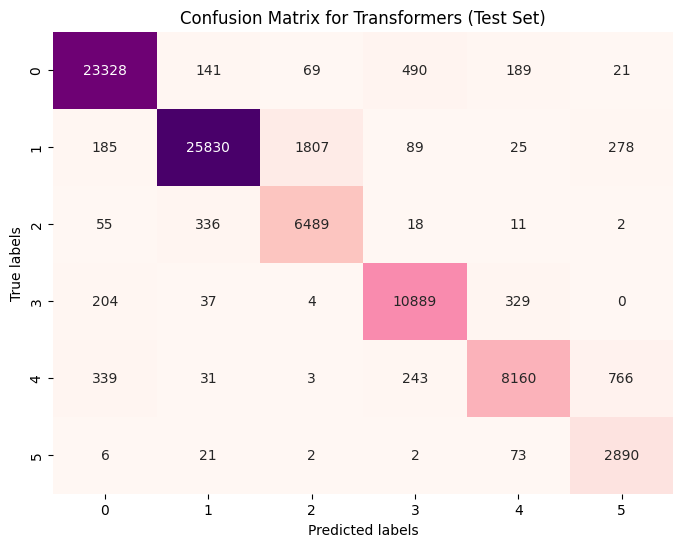

```python
cm = confusion_matrix(y_test_actual_labels, y_test_pred_labels)


plt.figure(figsize=(8, 6))
sns.heatmap(cm, annot=True, fmt='d', cmap='RdPu', cbar=False)
plt.xlabel('Predicted labels')
plt.ylabel('True labels')
plt.title('Confusion Matrix for Transformers (Test Set)')
plt.show()
```

We observe that despite the **unbalanced dataset**, the model performs quite well in classifying emotions — the highest values are on the diagonal of the matrix.

However, classification errors are visible.

The largest classification errors still occur between the same classes, confirming that there are certain similarities between these classes, and the model struggles to distinguish them.

```python
# Tokenization of new sentences
inputs = tokenizer(new_sentences, padding=True, truncation=True, return_tensors="pt", max_length=50)

# Model in evaluation mode (learning disabled)
model.eval()

# Prediction using the model
with torch.no_grad():
    outputs = model(**inputs)

# Logits obtained from the model.
logits = outputs.logits

# Conversion of logits into classes.
predictions = np.argmax(logits.numpy(), axis=1)

# Results
for sentence, pred in zip(new_sentences0, predictions):
    print(f"Sentence: '{sentence}' \nPredicted emotion: {labels[pred]}\n")
```

```
Sentence: 'i feel very discouraged and disappointed'
Predicted emotion: 0 - sadness

Sentence: 'i feel so empty inside...'
Predicted emotion: 0 - sadness

Sentence: 'i feel lucky to have so many nice people in my live'
Predicted emotion: 1 - joy

Sentence: 'I want to give him everything because loving him gives me everything.'
Predicted emotion: 0 - sadness

Sentence: 'i was feeling romantic'
Predicted emotion: 2 - love

Sentence: 'i feel so mad and confused again'
Predicted emotion: 3 - anger

Sentence: 'I went out for a walk at night on my own I lost my way and spent several minutes in the dark alley'
Predicted emotion: 4 - fear

Sentence: 'i got scared when i saw that i had to go through a dark alley'
Predicted emotion: 4 - fear

Sentence: 'i just feel really helpless and heavy hearted'
Predicted emotion: 4 - fear

Sentence: 'I just watched the documentary and Im impressed that he was such a great man'
Predicted emotion: 5 - surprise

Sentence: 'i feel amazing about using only natural mostly'
Predicted emotion: 5 - surprise

Sentence: 'i am feeling pretty impressed'
Predicted emotion: 5 - surprise
```

In this case, the model made a single error:

The sentence "I want to give him everything because loving him gives me everything." was misclassified as sadness (0 - sadness), although it conveys positive emotions of love (2 - love). This indicates that the model may have missed the full emotional nuance of the sentence.

##### Balanced dataset

```python
trainer_balanced = Trainer(
    model=model_balanced,
    args=training_args,
    train_dataset=dataset_train_balanced,
    eval_dataset=dataset_test_balanced,
    compute_metrics=compute_metrics,
    callbacks=[EarlyStoppingCallback(early_stopping_patience=2)]

)


trainer_balanced.train()
```

[1725/1725 33:57, Epoch 3/3]

| Epoch | Training Loss | Validation Loss | Accuracy | F1 |
| --- | --- | --- | --- | --- |
| 1 | 0.766400 | 0.294738 | 0.917351 | 0.916858 |
| 2 | 0.269000 | 0.215566 | 0.931404 | 0.931083 |
| 3 | 0.207400 | 0.199341 | 0.933700 | 0.933392 |

```
TrainOutput(global_step=1725, training_loss=0.4142746767790421, metrics={'train_runtime': 2038.9056, 'train_samples_per_second': 84.595, 'train_steps_per_second': 0.846, 'total_flos': 144954031483440.0, 'train_loss': 0.4142746767790421, 'epoch': 3.0})
```

Similar to the imbalanced dataset, key metrics such as Accuracy and F1-score are at very high levels, indicating the model's good generalization ability.

- *Epoch 1*: **Accuracy** = 0.9174, **F1** = 0.9169
- *Epoch 2*: **Accuracy** = 0.9314, **F1** = 0.9311
- *Epoch 3*: **Accuracy** = 0.9337, **F1** = 0.9333

Therefore, we can assume that the model is capable of effectively recognizing emotions in text.

#### Model Performance Evaluation

**Train Set**

```python
train_results_balanced = trainer_balanced.evaluate(dataset_train_balanced)
acc_train_transformers_balanced = round(train_results_balanced["eval_accuracy"],4)
f1_train_transformers_balanced = round(train_results_balanced["eval_f1"],4)

train_results_balanced
```

```
{'eval_loss': 0.1671389490365982,
 'eval_accuracy': 0.9430027481128466,
 'eval_f1': 0.942796873408719,
 'eval_runtime': 195.8599,
 'eval_samples_per_second': 293.546,
 'eval_steps_per_second': 2.936,
 'epoch': 3.0}
```

**Test Set**

```python
test_results_balanced = trainer_balanced.evaluate(dataset_test_balanced)
acc_test_transformers_balanced = round(test_results_balanced["eval_accuracy"],4)
f1_test_transformers_balanced = round(test_results_balanced["eval_f1"],4)

test_results_balanced
```

```
{'eval_loss': 0.19934086501598358,
 'eval_accuracy': 0.9336997356337832,
 'eval_f1': 0.9333924401684318,
 'eval_runtime': 49.0087,
 'eval_samples_per_second': 293.295,
 'eval_steps_per_second': 2.938,
 'epoch': 3.0}
```

The **loss** on the validation set is **0.1993**. The **accuracy** of the model on the validation set was around **0.9337**, which is a good result. This indicates the percentage of examples that were correctly classified. The **F1-score** is also high, at around **0.9334**.

On the balanced dataset, the loss value is slightly higher than on the imbalanced dataset (where it was 0.1223), but the accuracy (where it was 0.9307) and F1-score (where it was 0.9320) are slightly better.

#### Confusion Matrix (Test Set)

```python
y_test_predict_balanced = trainer_balanced.predict(dataset_test_balanced)

# Actual labels
y_test_actual_labels_balanced = y_test_predict_balanced.label_ids

# Predicted labels
y_test_pred_labels_balanced = np.argmax(tf.nn.softmax(y_test_predict_balanced.predictions), axis=1)
```

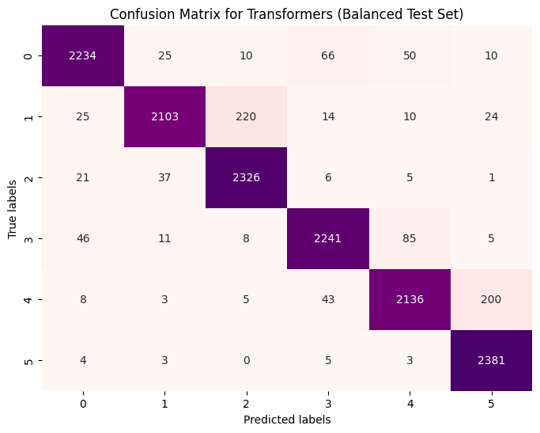

```python
cm = confusion_matrix(y_test_actual_labels_balanced, y_test_pred_labels_balanced)


plt.figure(figsize=(8, 6))
sns.heatmap(cm, annot=True, fmt='d', cmap='RdPu', cbar=False)
plt.xlabel('Predicted labels')
plt.ylabel('True labels')
plt.title('Confusion Matrix for Transformers (Balanced Test Set)')
plt.show()
```

The elements on the diagonal of the matrix (where the true labels match the predicted labels) have high values, indicating that the model correctly classifies most cases for each class.

However, we notice that the model incorrectly classifies texts in some instances. Most often, class 4 (*fear*) is confused with class 5 (*surprise*) — 200 cases. Similarly, class 1 (*joy*) is confused with class 2 (*love*) — 220 cases.

A review of previous models also shows that these same classes were often the source of the highest number of classification errors. This suggests that these emotions may be difficult to distinguish and that there are similarities in their interpretation, that make it difficult for models to correctly recognize them.

```python
# Model in evaluation mode (learning disabled)
model_balanced.eval()

# Prediction using the model
with torch.no_grad():
    outputs = model_balanced(**inputs)

# Logits obtained from the model
logits = outputs.logits

# Conversion of logits into classes
predictions = np.argmax(logits.numpy(), axis=1)


# Results
for sentence, pred in zip(new_sentences0, predictions):
    print(f"Sentence: '{sentence}' \nPredicted emotion: {labels[pred]}\n")
```

```
Sentence: 'i feel very discouraged and disappointed'
Predicted emotion: 0 - sadness

Sentence: 'i feel so empty inside...'
Predicted emotion: 0 - sadness

Sentence: 'i feel lucky to have so many nice people in my live'
Predicted emotion: 1 - joy

Sentence: 'I want to give him everything because loving him gives me everything.'
Predicted emotion: 2 - love

Sentence: 'i was feeling romantic'
Predicted emotion: 2 - love

Sentence: 'i feel so mad and confused again'
Predicted emotion: 3 - anger

Sentence: 'I went out for a walk at night on my own I lost my way and spent several minutes in the dark alley'
Predicted emotion: 3 - anger

Sentence: 'i got scared when i saw that i had to go through a dark alley'
Predicted emotion: 4 - fear

Sentence: 'i just feel really helpless and heavy hearted'
Predicted emotion: 4 - fear

Sentence: 'I just watched the documentary and Im impressed that he was such a great man'
Predicted emotion: 5 - surprise

Sentence: 'i feel amazing about using only natural mostly'
Predicted emotion: 5 - surprise

Sentence: 'i am feeling pretty impressed'
Predicted emotion: 5 - surprise
```

# Summary

The texts were **analyzed** and **processed**, and then three models were applied: **SVM**, **LSTM**, and **Transformers**, to create a solution capable of effectively recognizing emotions in various texts.

The results are as follows:

```python
results = {
    'SVM (Imbalanced)': [acc_train_svm, f1_train_svm, acc_test_svm, f1_test_svm],
    'SVM (Balanced)': [acc_train_svm_balanced, f1_train_svm_balanced, acc_test_svm_balanced, f1_test_svm_balanced],
    'LSTM (Imbalanced)': [acc_train_lstm, f1_train_lstm, acc_test_lstm, f1_test_lstm],
    'LSTM (Balanced)': [acc_train_lstm_balanced, f1_train_lstm_balanced, acc_test_lstm_balanced, f1_test_lstm_balanced],
    'Transformers (Imbalanced)': [acc_train_transformers, f1_train_transformers, acc_test_transformers, f1_test_transformers],
    'Transformers (Balanced)': [acc_train_transformers_balanced, f1_train_transformers_balanced, acc_test_transformers_balanced, f1_test_transformers_balanced]
}

df = pd.DataFrame(results, index=['Accuracy (Train set)', 'F1-score (Train set)', 'Accuracy (Test set)', 'F1-score (Test set)'])
df = df.T

#print(df)
print(tabulate(df, headers='keys', tablefmt='fancy_grid'))
```

```
╒═══════════════════════════╤════════════════════════╤════════════════════════╤═══════════════════════╤═══════════════════════╕
│                           │   Accuracy (Train set) │   F1-score (Train set) │   Accuracy (Test set) │   F1-score (Test set) │
╞═══════════════════════════╪════════════════════════╪════════════════════════╪═══════════════════════╪═══════════════════════╡
│ SVM (Imbalanced)          │                 0.9195 │                 0.9211 │                0.8835 │                0.8854 │
├───────────────────────────┼────────────────────────┼────────────────────────┼───────────────────────┼───────────────────────┤
│ SVM (Balanced)            │                 0.9526 │                 0.9524 │                0.8911 │                0.8908 │
├───────────────────────────┼────────────────────────┼────────────────────────┼───────────────────────┼───────────────────────┤
│ LSTM (Imbalanced)         │                 0.9388 │                 0.9394 │                0.9252 │                0.926  │
├───────────────────────────┼────────────────────────┼────────────────────────┼───────────────────────┼───────────────────────┤
│ LSTM (Balanced)           │                 0.9177 │                 0.9597 │                0.9244 │                0.9243 │
├───────────────────────────┼────────────────────────┼────────────────────────┼───────────────────────┼───────────────────────┤
│ Transformers (Imbalanced) │                 0.9364 │                 0.9376 │                0.9307 │                0.932  │
├───────────────────────────┼────────────────────────┼────────────────────────┼───────────────────────┼───────────────────────┤
│ Transformers (Balanced)   │                 0.943  │                 0.9428 │                0.9337 │                0.9334 │
╘═══════════════════════════╧════════════════════════╧════════════════════════╧═══════════════════════╧═══════════════════════╛
```

**Accuracy and F1-score give similar results**, but in the case of unevenly distributed data, F1-score provides a better picture of the model's performance. In this case, the differences in Accuracy and F1-score are minimal, suggesting that the models are relatively consistent in both metrics.

**Transformers** achieved **the highest values** for both **Accuracy** and **F1-score**, both on the unbalanced and balanced **test** datasets.

LSTM also achieved very good results, although slightly lower than Transformers. SVM achieved lower results than the other models.

**All models generalize well. However, Transformers achieve the highest results on the balanced dataset, suggesting that they are the most effective model in this analysis.**

Automatic emotion recognition enables efficient analysis of large sets of product and service reviews. This accelerates problem identification and enables the creation of more personalized offers.

In summary, integrating NLP-based emotion recognition tools offers many benefits to businesses. By understanding customer emotions, businesses can proactively solve problems, adapt their offers, and strengthen relationships, leading to lasting customer loyalty and long-term growth.